#7TotaldescriptivaClean5.Rmd

#install.packages(“rmarkdown”)

#library(“rmarkdown”)

Información para la modificación

Para instalar el latex para r poner el comando en la consola: tinytex::install_tinytex()

Algunos de los parametros de cada chunk de codigo para poder deshabilitar algunos outputs. No me sé los valores por defecto :)

include = FALSE prevents code and results from appearing in the finished file. R Markdown still runs the code in the chunk, and the results can be used by other chunks. echo = FALSE prevents code, but not the results from appearing in the finished file. This is a useful way to embed figures. message = FALSE prevents messages that are generated by code from appearing in the finished file. warning = FALSE prevents warnings that are generated by code from appearing in the finished. fig.cap = “…” adds a caption to graphical results.

Ponemos la carpeta en la que estamos y cargamos el dataset elegido

```r
setwd("/home/pablesky/Documentos/MD-FIB/Refactor")
dd<- read.csv("sinMissings.csv")
```

Variables en las que hemos utilizado knn para completar los missings

```r
pdf(file = 'PostprocesingResuts.pdf')
numVariables<-c(3, 4, 5, 7, 10, 11, 12, 13, 14, 15, 16, 17)
```

Imprimos alguna información importante sobre el dataset seleccionado como en este caso el número de filas, el número de columnas y el nombre de las columnas.

```r
class(dd)
```

```
## [1] "data.frame"
```

```r
dim(dd)
```

```
## [1] 99516    19
```

```r
filas<-dim(dd)[1]
columnas<-dim(dd)[2]

filas
```

```
## [1] 99516
```

```r
columnas
```

```
## [1] 19
```

```r
names(dd)
```

```
##  [1] "Row"     "Loc"     "MinT"    "MaxT"    "Rain"    "WDir"    "WSpeed"
##  [8] "WDir9"   "WDir3"   "WSpeed9" "WSpeed3" "Hum9"    "Hum3"    "Press9"
## [15] "Press3"  "Temp9"   "Temp3"   "Rtod"    "RTom"
```

Función dedicada a imprimir los datos en forma de gráficas de cada columna por individual, hay que intentar quitar la primera columna en el caso que la primera columna sea solamente RowX o el índice de la tabla.

```r
descriptiva<-function(X, nom){
  if (!(is.numeric(X) || class(X)=="Date")){
    frecs<-table(as.factor(X), useNA="ifany")
    proportions<-frecs/filas
    #ojo, decidir si calcular porcentages con o sin missing values
    pie(frecs, cex=0.6, main=paste("Pie of", nom))
    barplot(frecs, las=3, cex.names=0.7, main=paste("Barplot of", nom), col=listOfColors)
    print(paste("Number of modalities: ", length(frecs)))
    print("Frequency table")
    print(frecs)
    print("Relative frequency table (proportions)")
    print(proportions)
    print("Frequency table sorted")
    print(sort(frecs, decreasing=TRUE))
    print("Relative frequency table (proportions) sorted")
    print(sort(proportions, decreasing=TRUE))
   }else{
     if(class(X)=="Date"){
       print(summary(X))
       print(sd(X))
       #decide breaks: weeks, months, quarters...
       hist(X,breaks="weeks")
     }else{
       hist(X, main=paste("Histogram of", nom))
       boxplot(X, horizontal=TRUE, main=paste("Boxplot of",nom))
       print("Extended Summary Statistics")
       print(summary(X))
       print(paste("sd: ", sd(X, na.rm=TRUE)))
       print(paste("vc: ", sd(X, na.rm=TRUE)/mean(X, na.rm=TRUE)))
      }
   }
}
```

Ejecución de la función por cada columna. La variable c es el rango desde la columna inicial hasta la columna final, es decir si ponemos 1:23 hará la ejecución desde la primera columna hasta la columna 23.

Ponemos el 2 en el inicio del recorrido para skipear la columna de row.

```r
listOfColors<-rainbow(39)

actives<-c(2:columnas)

par(ask=TRUE)
for(k in actives){
  print(paste("variable ", k, ":", names(dd)[k] ))
  descriptiva(dd[,k], names(dd)[k])
}
```

```
## [1] "variable  2 : Loc"
```

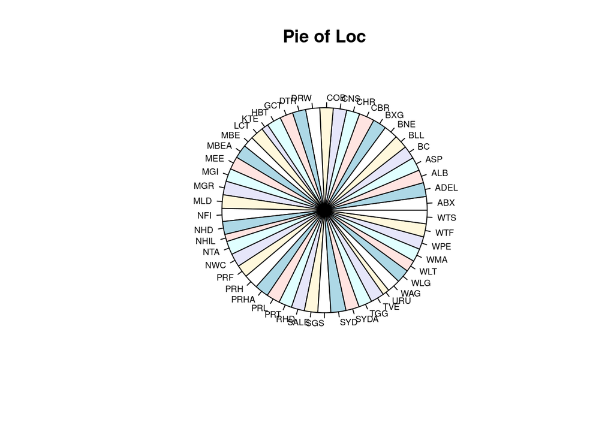

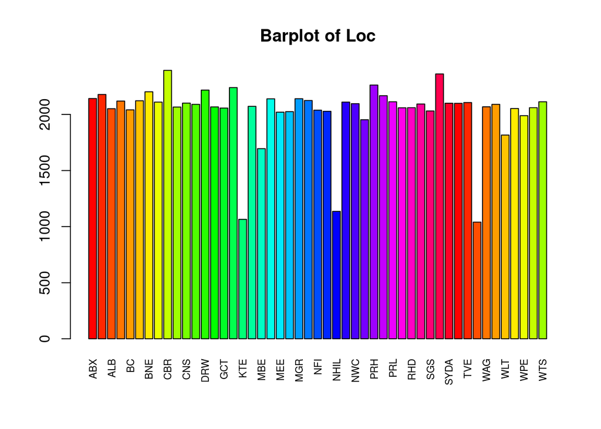

```
## [1] "Number of modalities:  49"
## [1] "Frequency table"
##
##  ABX ADEL  ALB  ASP   BC  BLL  BNE  BXG  CBR  CHR  CNS  COB  DRW  DTR  GCT  HBT
## 2142 2178 2051 2119 2041 2122 2202 2110 2393 2066 2101 2090 2217 2067 2057 2239
##  KTE  LCT  MBE MBEA  MEE  MGI  MGR  MLD  NFI  NHD NHIL  NTA  NWC  PRF  PRH PRHA
## 1065 2072 1695 2139 2020 2025 2140 2124 2038 2028 1136 2110 2096 1953 2262 2167
##  PRL  PRT  RHD SALE  SGS  SYD SYDA  TGG  TVE  URU  WAG  WLG  WLT  WMA  WPE  WTF
## 2113 2059 2060 2093 2031 2361 2100 2099 2106 1040 2068 2090 1816 2053 1989 2060
##  WTS
## 2113
## [1] "Relative frequency table (proportions)"
##
##        ABX       ADEL        ALB        ASP         BC        BLL        BNE
## 0.02152418 0.02188593 0.02060975 0.02129306 0.02050926 0.02132320 0.02212710
##        BXG        CBR        CHR        CNS        COB        DRW        DTR
## 0.02120262 0.02404638 0.02076048 0.02111218 0.02100165 0.02227782 0.02077053
##        GCT        HBT        KTE        LCT        MBE       MBEA        MEE
## 0.02067004 0.02249889 0.01070180 0.02082077 0.01703244 0.02149403 0.02029824
##        MGI        MGR        MLD        NFI        NHD       NHIL        NTA
## 0.02034849 0.02150408 0.02134330 0.02047912 0.02037863 0.01141525 0.02120262
##        NWC        PRF        PRH       PRHA        PRL        PRT        RHD
## 0.02106194 0.01962498 0.02273001 0.02177539 0.02123277 0.02069014 0.02070019
##       SALE        SGS        SYD       SYDA        TGG        TVE        URU
## 0.02103179 0.02040878 0.02372483 0.02110213 0.02109209 0.02116243 0.01045058
##        WAG        WLG        WLT        WMA        WPE        WTF        WTS
## 0.02078058 0.02100165 0.01824832 0.02062985 0.01998674 0.02070019 0.02123277
## [1] "Frequency table sorted"
##
##  CBR  SYD  PRH  HBT  DRW  BNE ADEL PRHA  ABX  MGR MBEA  MLD  BLL  ASP  PRL  WTS
## 2393 2361 2262 2239 2217 2202 2178 2167 2142 2140 2139 2124 2122 2119 2113 2113
##  BXG  NTA  TVE  CNS SYDA  TGG  NWC SALE  COB  WLG  LCT  WAG  DTR  CHR  RHD  WTF
## 2110 2110 2106 2101 2100 2099 2096 2093 2090 2090 2072 2068 2067 2066 2060 2060
##  PRT  GCT  WMA  ALB   BC  NFI  SGS  NHD  MGI  MEE  WPE  PRF  WLT  MBE NHIL  KTE
## 2059 2057 2053 2051 2041 2038 2031 2028 2025 2020 1989 1953 1816 1695 1136 1065
##  URU
## 1040
## [1] "Relative frequency table (proportions) sorted"
##
##        CBR        SYD        PRH        HBT        DRW        BNE       ADEL
## 0.02404638 0.02372483 0.02273001 0.02249889 0.02227782 0.02212710 0.02188593
##       PRHA        ABX        MGR       MBEA        MLD        BLL        ASP
## 0.02177539 0.02152418 0.02150408 0.02149403 0.02134330 0.02132320 0.02129306
##        PRL        WTS        BXG        NTA        TVE        CNS       SYDA
## 0.02123277 0.02123277 0.02120262 0.02120262 0.02116243 0.02111218 0.02110213
##        TGG        NWC       SALE        COB        WLG        LCT        WAG
## 0.02109209 0.02106194 0.02103179 0.02100165 0.02100165 0.02082077 0.02078058
##        DTR        CHR        RHD        WTF        PRT        GCT        WMA
## 0.02077053 0.02076048 0.02070019 0.02070019 0.02069014 0.02067004 0.02062985
##        ALB         BC        NFI        SGS        NHD        MGI        MEE
## 0.02060975 0.02050926 0.02047912 0.02040878 0.02037863 0.02034849 0.02029824
##        WPE        PRF        WLT        MBE       NHIL        KTE        URU
## 0.01998674 0.01962498 0.01824832 0.01703244 0.01141525 0.01070180 0.01045058
## [1] "variable  3 : MinT"
```

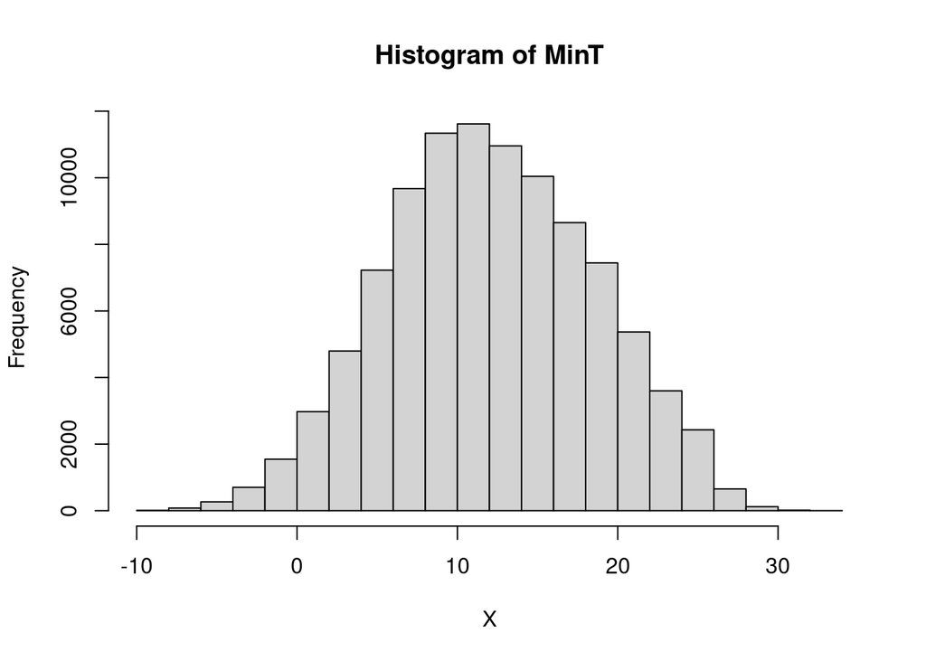

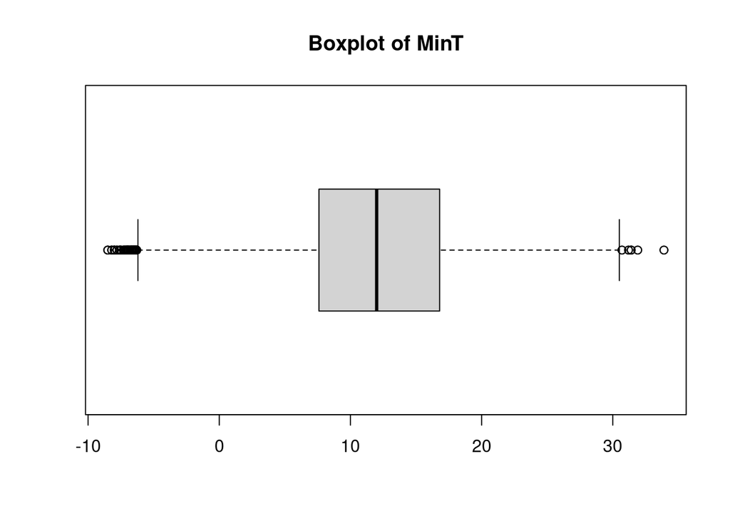

```
## [1] "Extended Summary Statistics"
##    Min. 1st Qu.  Median    Mean 3rd Qu.    Max.
##   -8.50    7.60   12.00   12.16   16.80   33.90
## [1] "sd:  6.42828023448271"
## [1] "vc:  0.528501649708804"
## [1] "variable  4 : MaxT"
```

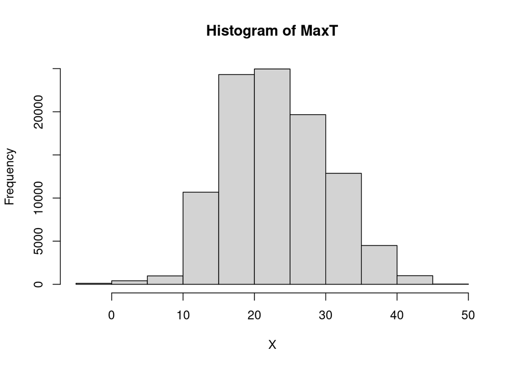

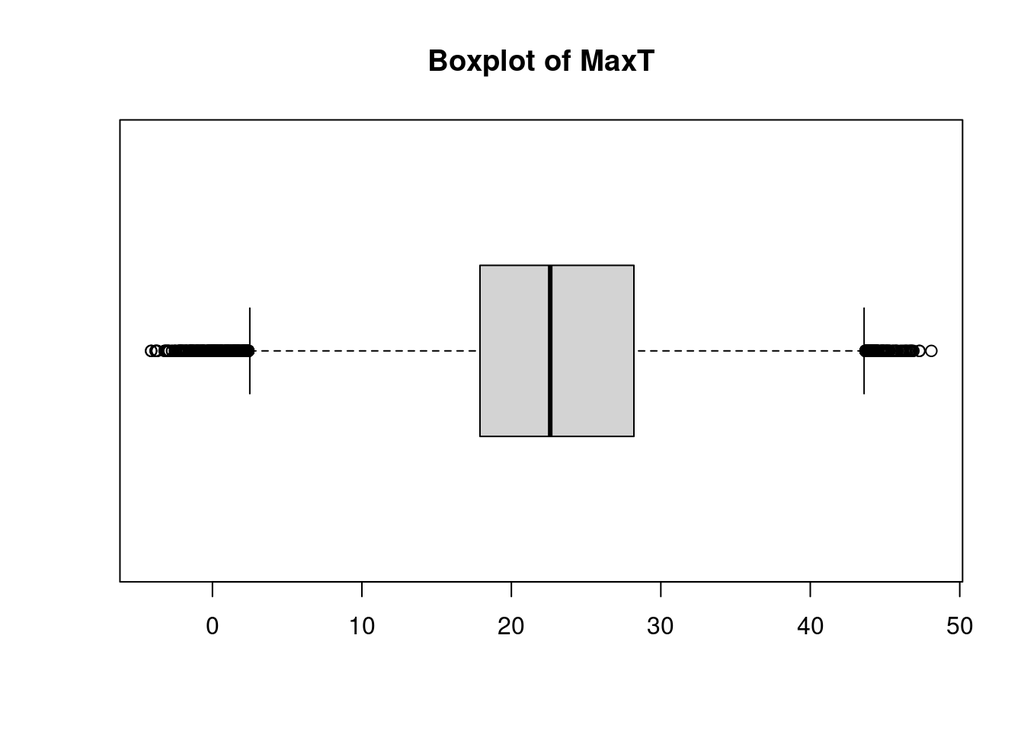

```
## [1] "Extended Summary Statistics"
##    Min. 1st Qu.  Median    Mean 3rd Qu.    Max.
##   -4.10   17.90   22.60   23.18   28.20   48.10
## [1] "sd:  7.14994688773191"
## [1] "vc:  0.308398791567923"
## [1] "variable  5 : Rain"
```

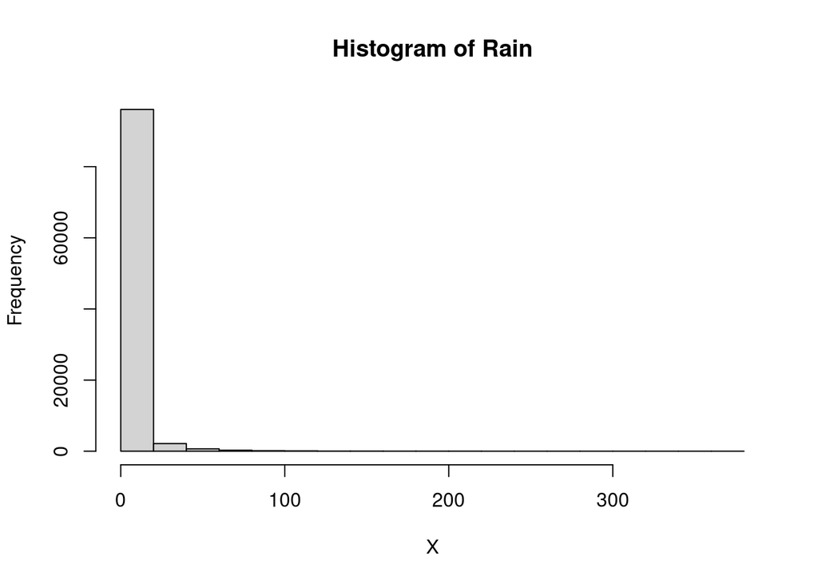

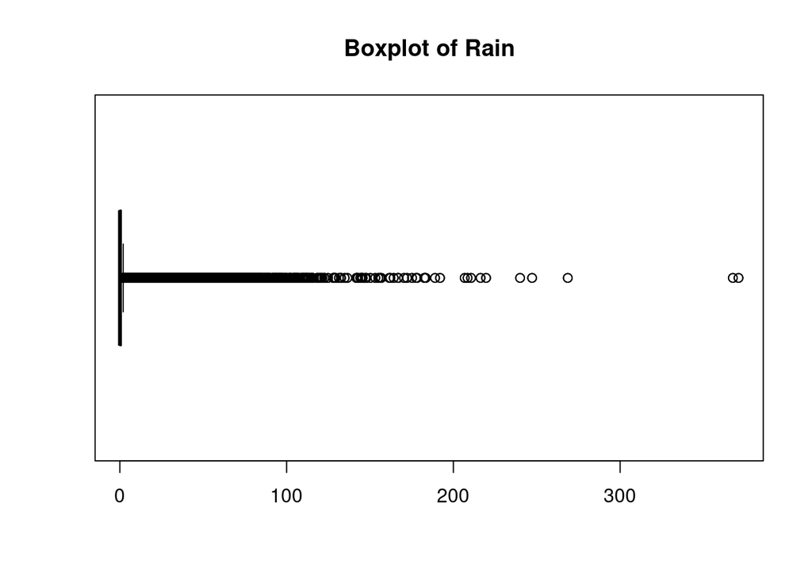

```
## [1] "Extended Summary Statistics"
##    Min. 1st Qu.  Median    Mean 3rd Qu.    Max.
##   0.000   0.000   0.000   2.776   0.800 371.000
## [1] "sd:  10.3607791555035"
## [1] "vc:  3.73246392090662"
## [1] "variable  6 : WDir"
```

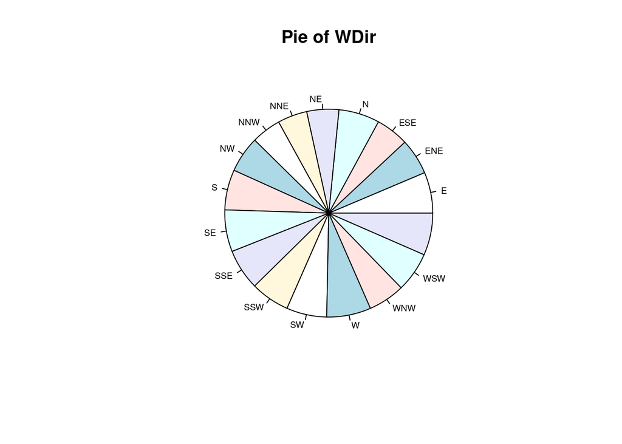

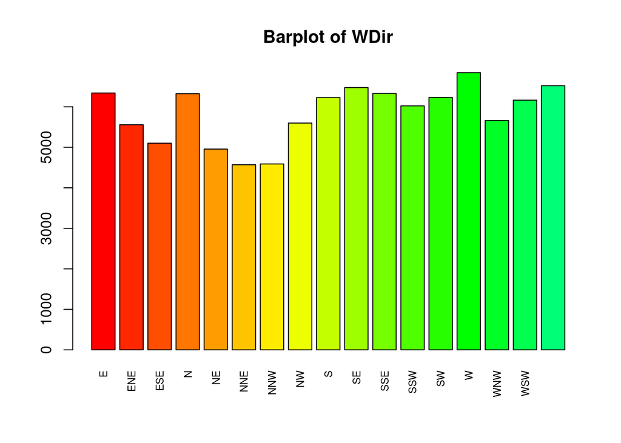

```
## [1] "Number of modalities:  17"
## [1] "Frequency table"
##
##    E  ENE  ESE    N   NE  NNE  NNW   NW    S   SE  SSE  SSW   SW    W  WNW  WSW
## 6341 5558 5101 6323 4956 4569 4589 5599 6228 6475 6329 6023 6233 6843 5664 6164
## <NA>
## 6521
## [1] "Relative frequency table (proportions)"
##
##          E        ENE        ESE          N         NE        NNE        NNW
## 0.06371840 0.05585032 0.05125809 0.06353752 0.04980104 0.04591222 0.04611319
##         NW          S         SE        SSE        SSW         SW          W
## 0.05626231 0.06258290 0.06506491 0.06359781 0.06052293 0.06263314 0.06876281
##        WNW        WSW       <NA>
## 0.05691547 0.06193979 0.06552715
## [1] "Frequency table sorted"
##
##    W <NA>   SE    E  SSE    N   SW    S  WSW  SSW  WNW   NW  ENE  ESE   NE  NNW
## 6843 6521 6475 6341 6329 6323 6233 6228 6164 6023 5664 5599 5558 5101 4956 4589
##  NNE
## 4569
## [1] "Relative frequency table (proportions) sorted"
##
##          W       <NA>         SE          E        SSE          N         SW
## 0.06876281 0.06552715 0.06506491 0.06371840 0.06359781 0.06353752 0.06263314
##          S        WSW        SSW        WNW         NW        ENE        ESE
## 0.06258290 0.06193979 0.06052293 0.05691547 0.05626231 0.05585032 0.05125809
##         NE        NNW        NNE
## 0.04980104 0.04611319 0.04591222
## [1] "variable  7 : WSpeed"
```

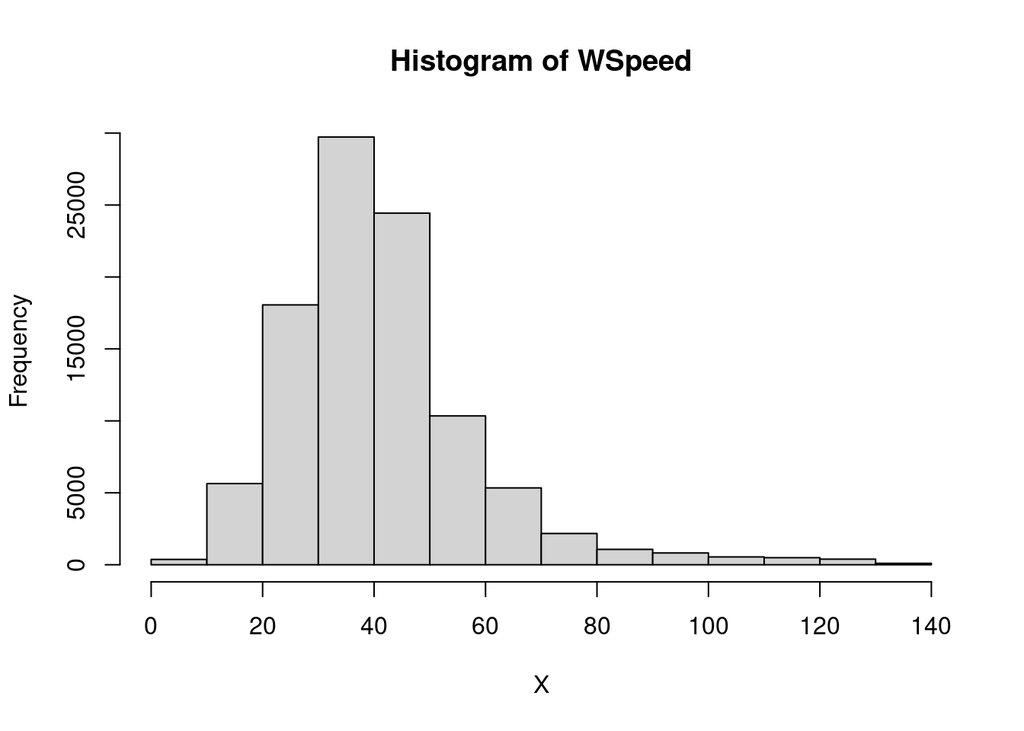

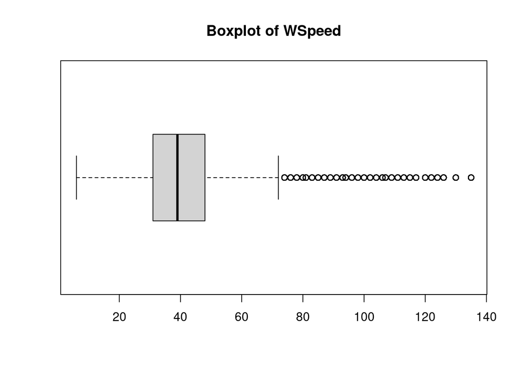

```
## [1] "Extended Summary Statistics"
##    Min. 1st Qu.  Median    Mean 3rd Qu.    Max.
##    6.00   31.00   39.00   41.72   48.00  135.00
## [1] "sd:  17.3717079868034"
## [1] "vc:  0.416347353089721"
## [1] "variable  8 : WDir9"
```

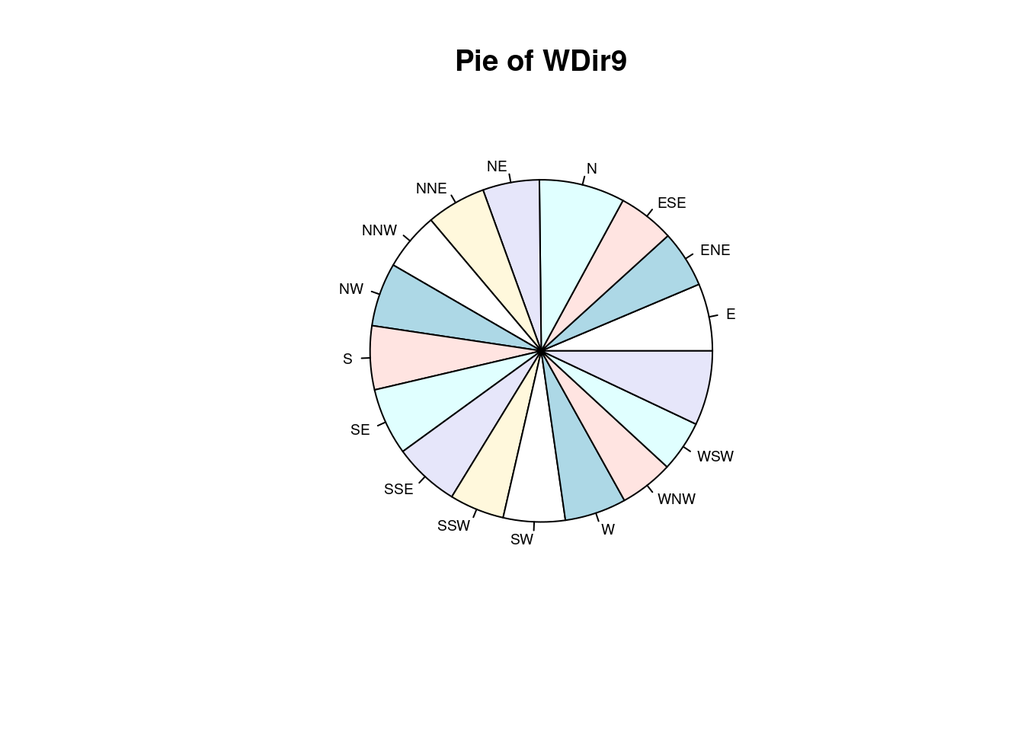

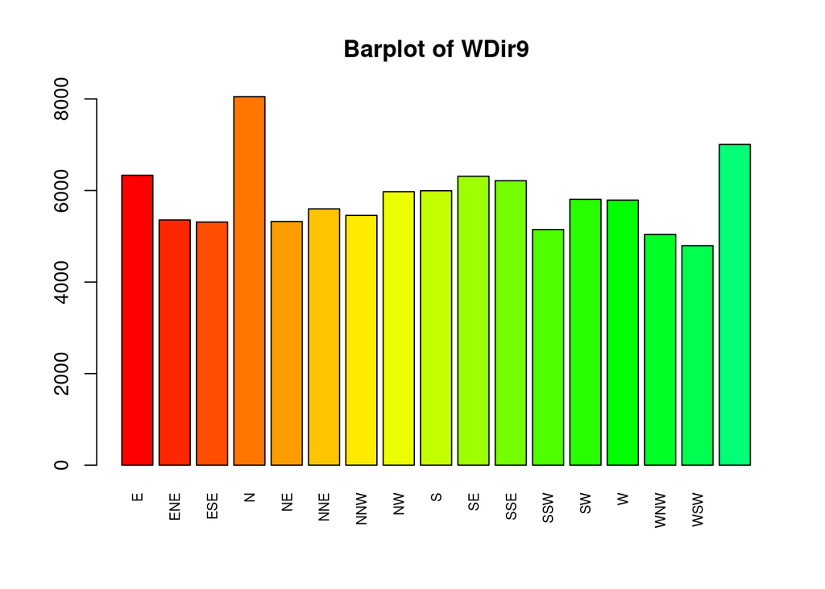

```
## [1] "Number of modalities:  17"
## [1] "Frequency table"
##
##    E  ENE  ESE    N   NE  NNE  NNW   NW    S   SE  SSE  SSW   SW    W  WNW  WSW
## 6333 5357 5312 8052 5323 5600 5457 5975 5995 6311 6214 5147 5808 5790 5041 4795
## <NA>
## 7006
## [1] "Relative frequency table (proportions)"
##
##          E        ENE        ESE          N         NE        NNE        NNW
## 0.06363801 0.05383054 0.05337835 0.08091161 0.05348889 0.05627236 0.05483540
##         NW          S         SE        SSE        SSW         SW          W
## 0.06004060 0.06024157 0.06341694 0.06244222 0.05172033 0.05836247 0.05818160
##        WNW        WSW       <NA>
## 0.05065517 0.04818321 0.07040074
## [1] "Frequency table sorted"
##
##    N <NA>    E   SE  SSE    S   NW   SW    W  NNE  NNW  ENE   NE  ESE  SSW  WNW
## 8052 7006 6333 6311 6214 5995 5975 5808 5790 5600 5457 5357 5323 5312 5147 5041
##  WSW
## 4795
## [1] "Relative frequency table (proportions) sorted"
##
##          N       <NA>          E         SE        SSE          S         NW
## 0.08091161 0.07040074 0.06363801 0.06341694 0.06244222 0.06024157 0.06004060
##         SW          W        NNE        NNW        ENE         NE        ESE
## 0.05836247 0.05818160 0.05627236 0.05483540 0.05383054 0.05348889 0.05337835
##        SSW        WNW        WSW
## 0.05172033 0.05065517 0.04818321
## [1] "variable  9 : WDir3"
```

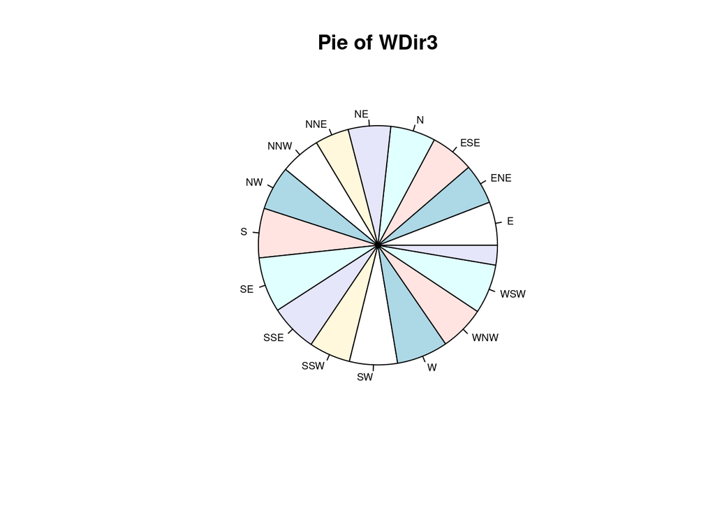

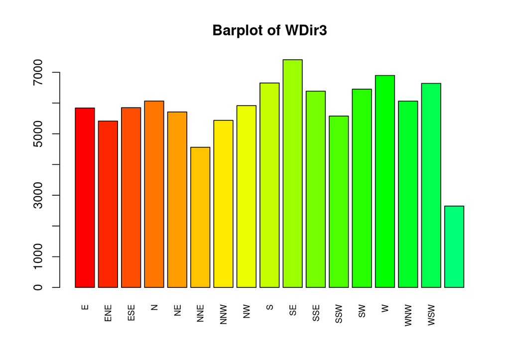

```
## [1] "Number of modalities:  17"
## [1] "Frequency table"
##
##    E  ENE  ESE    N   NE  NNE  NNW   NW    S   SE  SSE  SSW   SW    W  WNW  WSW
## 5839 5413 5850 6065 5710 4561 5437 5917 6653 7410 6386 5576 6451 6897 6063 6640
## <NA>
## 2648
## [1] "Relative frequency table (proportions)"
##
##          E        ENE        ESE          N         NE        NNE        NNW
## 0.05867398 0.05439326 0.05878452 0.06094497 0.05737771 0.04583183 0.05463443
##         NW          S         SE        SSE        SSW         SW          W
## 0.05945778 0.06685357 0.07446039 0.06417059 0.05603119 0.06482375 0.06930544
##        WNW        WSW       <NA>
## 0.06092488 0.06672294 0.02660879
## [1] "Frequency table sorted"
##
##   SE    W    S  WSW   SW  SSE    N  WNW   NW  ESE    E   NE  SSW  NNW  ENE  NNE
## 7410 6897 6653 6640 6451 6386 6065 6063 5917 5850 5839 5710 5576 5437 5413 4561
## <NA>
## 2648
## [1] "Relative frequency table (proportions) sorted"
##
##         SE          W          S        WSW         SW        SSE          N
## 0.07446039 0.06930544 0.06685357 0.06672294 0.06482375 0.06417059 0.06094497
##        WNW         NW        ESE          E         NE        SSW        NNW
## 0.06092488 0.05945778 0.05878452 0.05867398 0.05737771 0.05603119 0.05463443
##        ENE        NNE       <NA>
## 0.05439326 0.04583183 0.02660879
## [1] "variable  10 : WSpeed9"
```

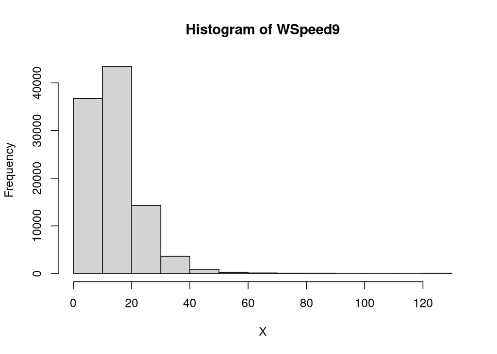

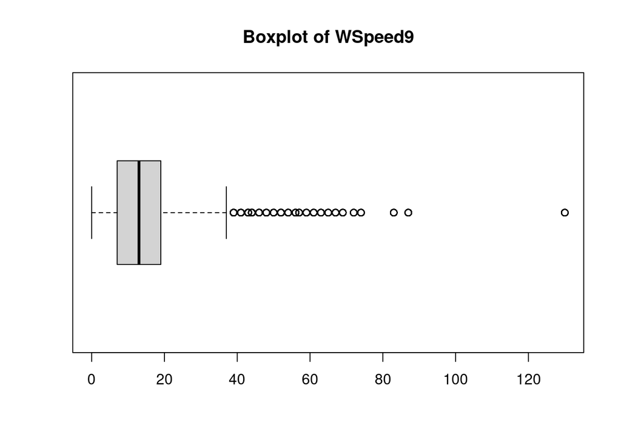

```
## [1] "Extended Summary Statistics"
##    Min. 1st Qu.  Median    Mean 3rd Qu.    Max.
##    0.00    7.00   13.00   14.25   19.00  130.00
## [1] "sd:  9.57382352002353"
## [1] "vc:  0.671772891725538"
## [1] "variable  11 : WSpeed3"
```

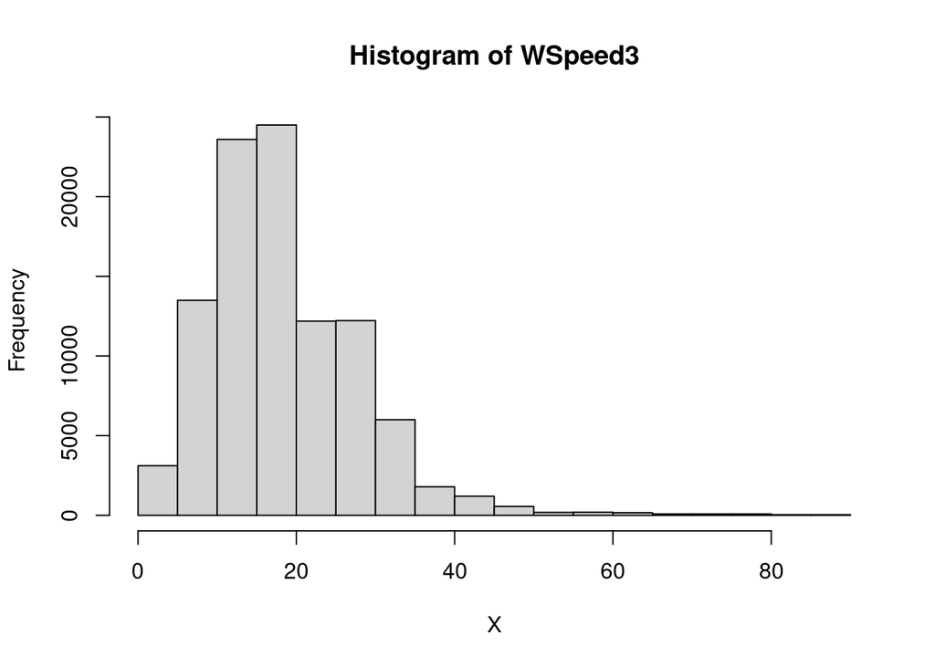

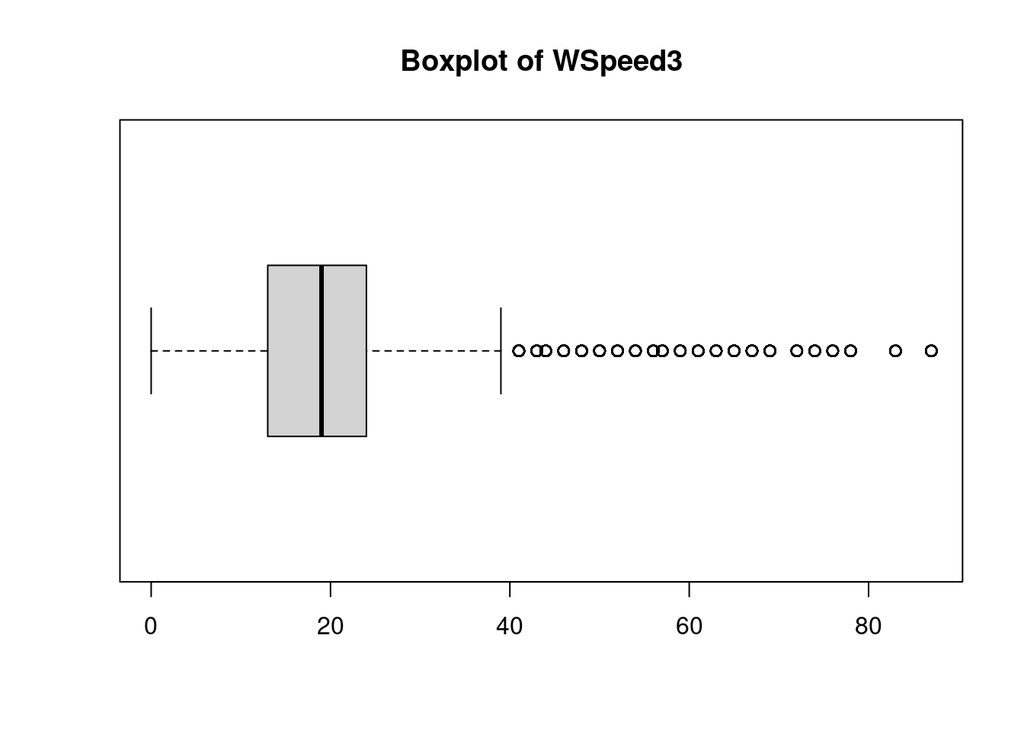

```
## [1] "Extended Summary Statistics"
##    Min. 1st Qu.  Median    Mean 3rd Qu.    Max.
##    0.00   13.00   19.00   19.05   24.00   87.00
## [1] "sd:  9.75529427493732"
## [1] "vc:  0.512204792180795"
## [1] "variable  12 : Hum9"
```

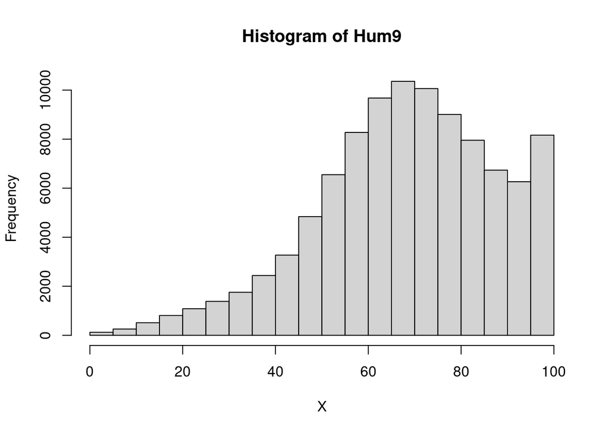

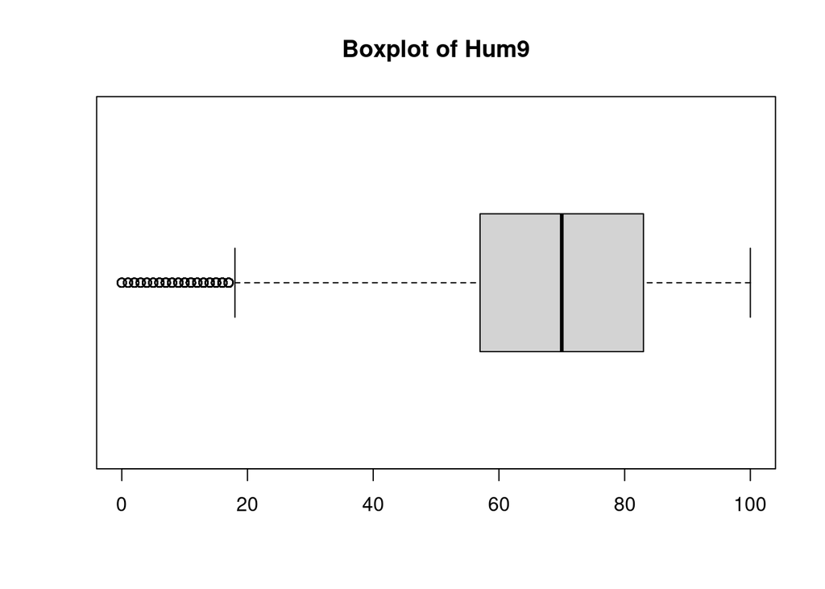

```
## [1] "Extended Summary Statistics"
##    Min. 1st Qu.  Median    Mean 3rd Qu.    Max.
##    0.00   57.00   70.00   68.62   83.00  100.00
## [1] "sd:  19.3575086839298"
## [1] "vc:  0.28207999558806"
## [1] "variable  13 : Hum3"
```

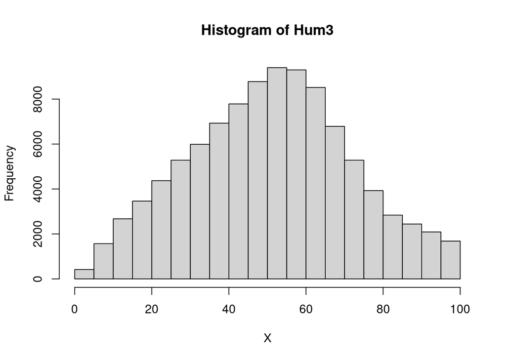

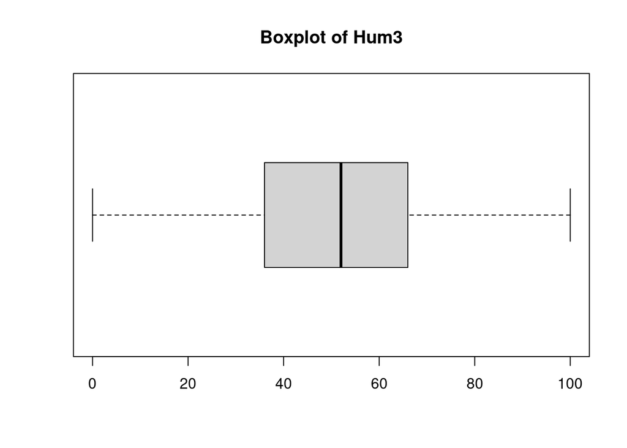

```
## [1] "Extended Summary Statistics"
##    Min. 1st Qu.  Median    Mean 3rd Qu.    Max.
##    0.00   36.00   52.00   51.39   66.00  100.00
## [1] "sd:  21.0273783877057"
## [1] "vc:  0.409177550076294"
## [1] "variable  14 : Press9"
```

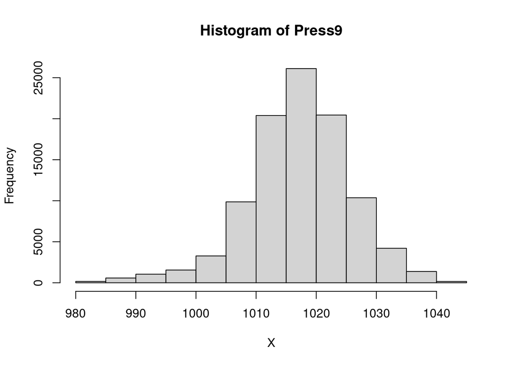

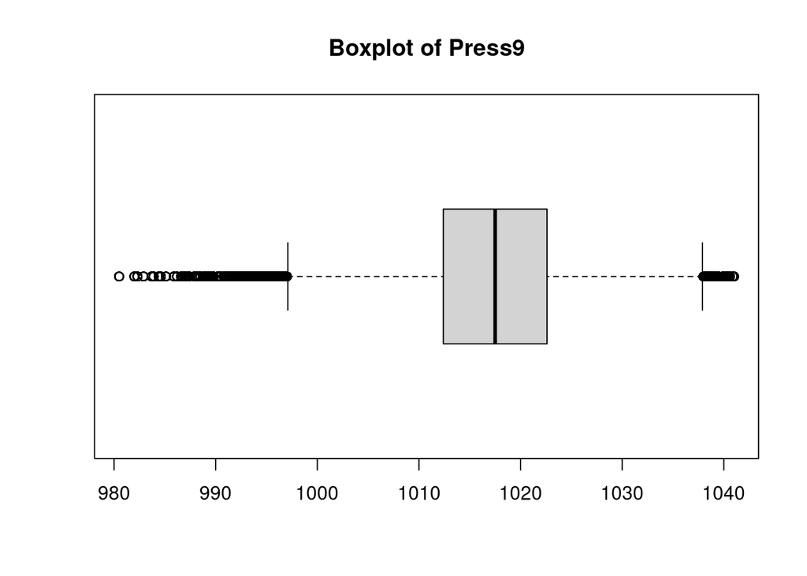

```
## [1] "Extended Summary Statistics"
##    Min. 1st Qu.  Median    Mean 3rd Qu.    Max.
##   980.5  1012.4  1017.5  1017.3  1022.6  1041.0
## [1] "sd:  8.46658383136427"
## [1] "vc:  0.00832296302363373"
## [1] "variable  15 : Press3"
```

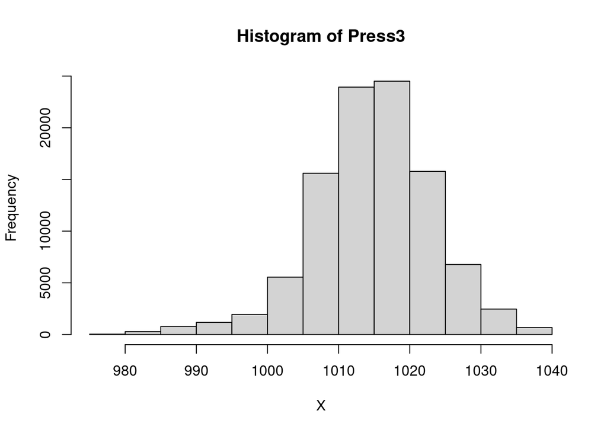

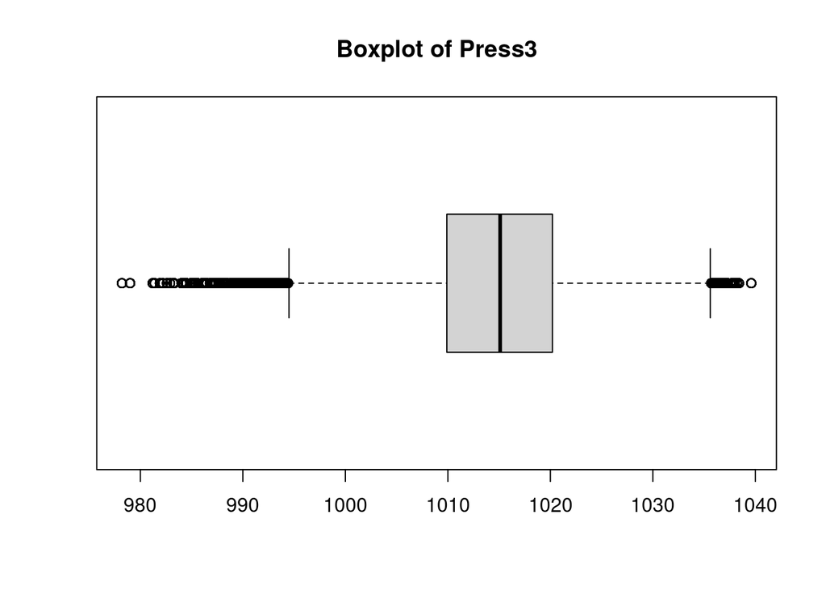

```
## [1] "Extended Summary Statistics"
##    Min. 1st Qu.  Median    Mean 3rd Qu.    Max.
##   978.2  1009.9  1015.1  1014.9  1020.2  1039.6
## [1] "sd:  8.39280257994527"
## [1] "vc:  0.00826980503693597"
## [1] "variable  16 : Temp9"
```

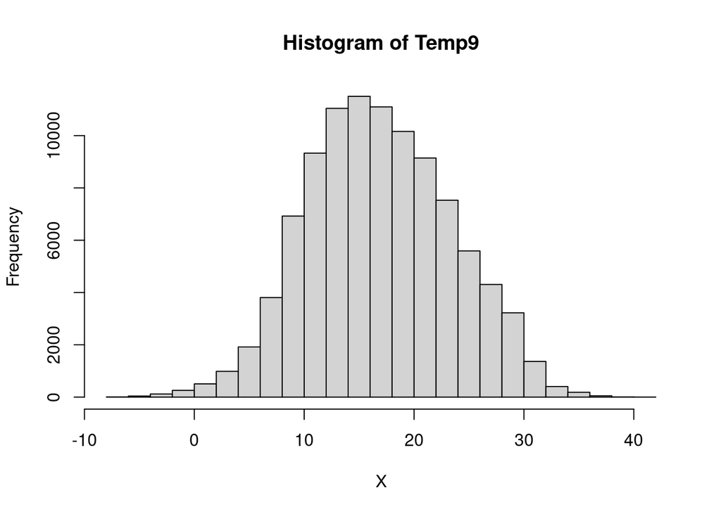

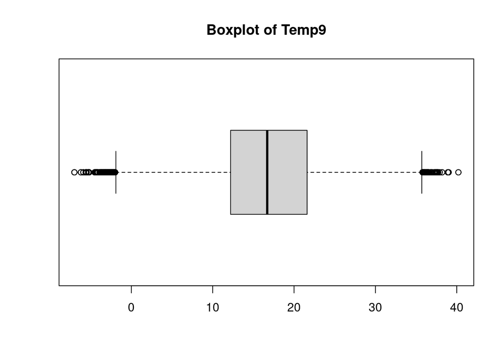

```
## [1] "Extended Summary Statistics"
##    Min. 1st Qu.  Median    Mean 3rd Qu.    Max.
##   -7.00   12.20   16.70   16.94   21.60   40.20
## [1] "sd:  6.5492471169014"
## [1] "vc:  0.3865256741186"
## [1] "variable  17 : Temp3"
```

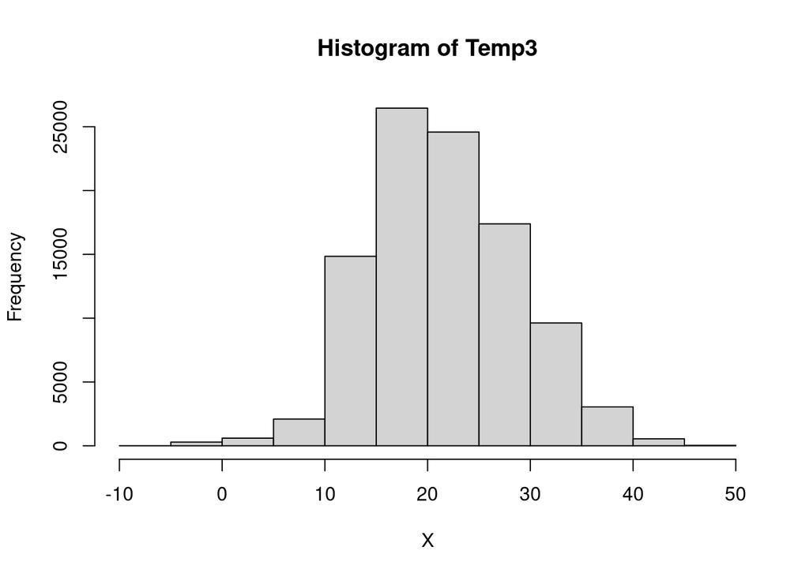

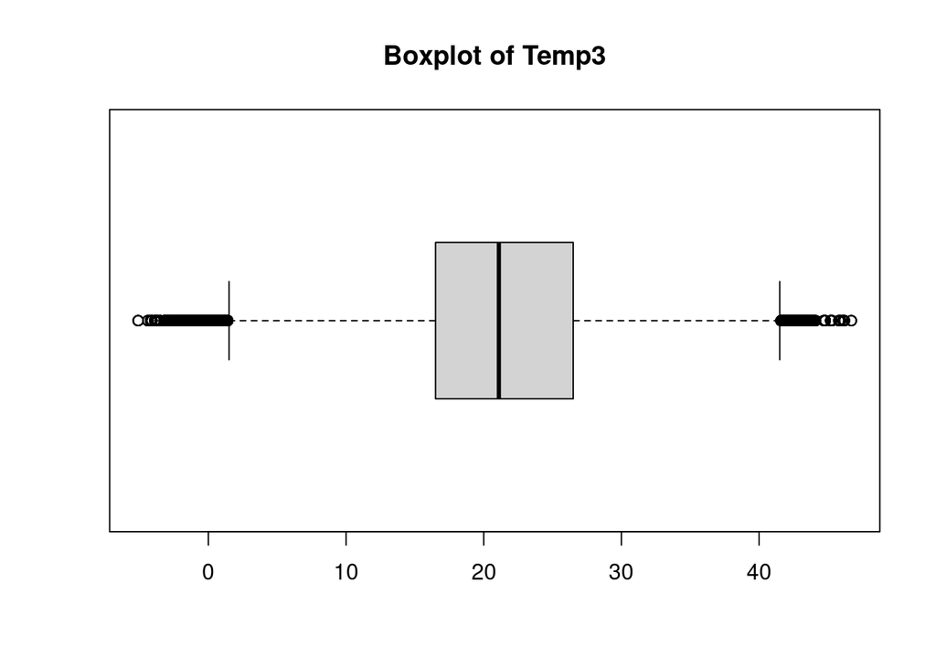

```
## [1] "Extended Summary Statistics"
##    Min. 1st Qu.  Median    Mean 3rd Qu.    Max.
##   -5.10   16.50   21.10   21.65   26.50   46.70
## [1] "sd:  7.13362646119661"
## [1] "vc:  0.329560396055767"
## [1] "variable  18 : Rtod"
```